# *ELEN90097 Workshop 2 – Modelling and Analysis for AI*

This workshop is allocated 3 weeks.

## Topics Covered

This workshop will cover the fundamentals of data types/structures and algorithms with an emphasis on recursion and dynamic programming.

- Data types and structures
  - Sets
  - Stacks, queues
  - Graphs, trees
- Algorithms
  - Recursion, dynamic programming
  - Sorting, search

## Workflow and Assessment

This subject follows a problem- and project-oriented approach. This learning workflow focuses on solving practical (engineering) problems, which motivates acquiring theoretical (background) knowledge.

### Objectives

- Use these problems as a motivation to learn the fundamentals covered in lectures.
- Learn how to formulate and solve problems in practice.
- Familiarise yourself with practical software tools.
- Connect theoretical and practical knowledge by doing it yourself.

The goal is to gain hands-on experience and learn by doing! Understand how theoretical knowledge discussed in lectures relates to practice. Develop motivation for gaining further theoretical and practical knowledge beyond the subject material.

> **Self-learning** is one of the most important skills you should acquire as a student. Today, self-learning is much easier than it used to be thanks to many online resources.

### Assessment Process

1. Follow the procedures described below, perform the given tasks, and answer the workshop questions **in this Python/Jupyter notebook! The resulting notebook will be your Workshop Report!**
2. Submit the workshop report at the announced deadline
3. Demonstrators will conduct a brief oral quiz on your submitted report in the subsequent weeks.
4. Your workshop marks will be based on the report you will submit and oral quiz results (with a heavy weight on the oral component).

> **The goal is to learn**, NOT blindly follow the procedures in the fastest possible way! **Do not simply copy-paste answers (from the Internet, friends, etc.). You can and should use all available resources but only to improve your understanding. If you copy-paste, you may perform poorly on the oral quiz!**

### Notes

- Use the table of contents feature of Jupyter Notebook for your convenience, see View menu above, Table of Contents. You can also turn on section numbers there if you wish.
- Similarly, you can turn on "show line numbers" in the same menu.

# Data Types and Structures

A data structure is a data organization and storage format on a computer. As you can imagine there are many ways of organising and storing data. Therefore, different programming languages approach this in different ways. Usually, high-level programming languages like Python provide many convenient *built-in* data structures, whereas low-level system languages like C only provide basic data types. In both cases, external libraries such as [Numpy](https://numpy.org) provide additional support for advanced data structures (e.g. vectors and matrices in the case of Numpy).

In this subject, we will focus on **Python** which famously adopts a [``batteries included" philosophy](https://peps.python.org/pep-0206/). This does *not* mean Python has the best data structures ever. It just means we want consistency over our AI subjects and Python is the current popular language in AI/ML, and a comparative study of data structures of languages is beyond our scope.

### Python Data Types, Structures, and Libraries

Python has a lot of built-in [datatypes](https://docs.python.org/3/library/datatypes.html). You don't need to know them all and you can learn about them as you need. There are many tutorials online on this topic such as [this one](https://www.w3schools.com/python/python_datatypes.asp).

In addition to built-in data types, there are many respected libraries in Python providing advanced data structures such as [Numpy](https://numpy.org) (vectors, matrices, Matlab-like functionality), [NetworkX](https://networkx.org) (data structures for graphs), etc.

### Next Step: a selective tour

*You should already know about the basics of Python built-in basic data types such as lists, strings, and dictionaries.* This workshop is not about learning Python basics and we don't have time to cover all data structures, either. Therefore, we will go over a few interesting, engineering-relevant data types and structures with selected examples and exercises.

## Sets in Python

A [set](https://www.w3schools.com/python/python_sets.asp) in Python is an unordered collection data type that is iterable and has no duplicate elements. This matches quite perfectly with the mathematical definition we know since primary school. There are many nice tutorials on the topic, see for example, [this one](https://www.geeksforgeeks.org/sets-in-python/) or [this](https://www.analyticsvidhya.com/blog/2021/07/an-intuitive-and-easy-guide-to-python-set-must-for-becoming-data-science-professional/) or [these exercises](https://www.w3resource.com/python-exercises/sets/).

Let's play with Python sets a bit.

```python
import numpy as np
import matplotlib.pyplot as plt
%matplotlib inline
```

```python
myset = {"Geeks", "for", "Geeks"}
print(type(myset))  # type of variable
print(myset)        # note no duplicates allowed!
print(len(myset))   # cardinality of the set
```

```
<class 'set'>
{'Geeks', 'for'}
2
```

## Question: Basic Set Operations in Python

We are given the sets $𝐴 = \{2, 3, 4, 5, 6\}$, $𝐵 = \{4, 5, 6, 7, 8\}$, and $𝐶 = \{3, 6, 8\}$.

1. Define these sets in Python.
2. Find $A \cup B$, $A \cap B$, $A \setminus B$, and cardinalities of these.
3. Try a few of the basic [set methods](https://www.w3schools.com/python/python_sets_methods.asp) but don't lose to much time on this.
4. [*Optional*] If you wish you can visualize these using the nice [Matplotlib-venn](https://github.com/konstantint/matplotlib-venn) library. But first, you need to install it. `!pip install matplotlib-venn`

**Answer as text here**

```python
''' Answer as code here '''
import matplotlib
A = set({2,3,4,5,6})
B = set({4,5,6,7,8})
C = set({3, 6, 8})
print("intersection: ",A.intersection(B))
print("union: ",A.union(B))
print("difference: ",A.difference(B))
```

```
intersection:  {4, 5, 6}
union:  {2, 3, 4, 5, 6, 7, 8}
difference:  {2, 3}
```

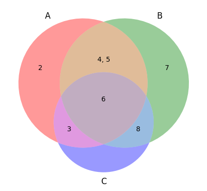

```python
import matplotlib_venn

v = matplotlib_venn.venn3([A, B, C], set_labels=["A", "B", "C"])

v.get_label_by_id("100").set_text(', '.join(str(item) for item in A.difference(B).difference(C)))
v.get_label_by_id('010').set_text(', '.join(str(item) for item in B.difference(A).difference(C)))
v.get_label_by_id('001').set_text(', '.join(str(item) for item in C.difference(A).difference(B)))
v.get_label_by_id('110').set_text(', '.join(str(item) for item in A.intersection(B).difference(C)))
v.get_label_by_id('011').set_text(', '.join(str(item) for item in B.intersection(C).difference(A)))
v.get_label_by_id('101').set_text(', '.join(str(item) for item in A.intersection(C).difference(B)))
v.get_label_by_id('111').set_text(', '.join(str(item) for item in A.intersection(B).intersection(C)))
```

## Stacks and Queues in Python

[figure not shown]

**Stack** is an old datatype, that goes back to the 1940s. In addition to software, stacks are implemented at the hardware level (CPU, memory, controllers) as a means of allocating and accessing memory.

[This is a nice tutorial on stacks](https://www.geeksforgeeks.org/stack-in-python/) in Python. Note that you can implement them in 3 different ways! For the following exercise, your choice does not matter. You can use a list or [collections.deque](https://docs.python.org/3/library/collections.html#deque-objects)

[figure not shown]

A **queue** is an ordered collection of items. Queues are widely used in engineering and IT and there is the entire mathematical field of *queueing theory* which studies queues and their properties.

As in the case of stacks, there are multiple options for [implementing queues in Python](https://realpython.com/queue-in-python/#implementing-queues-in-python). However, there is a nice [queue class already built in](https://docs.python.org/3/library/queue.html).

## Question: Balanced Parentheses using Stack Data Type

Solve the [balanced parenthesis checker](https://runestone.academy/ns/books/published/pythonds/BasicDS/SimpleBalancedParentheses.html) problem discussed in the lectures. The goal is to write an algorithm that will read a string of parentheses from left to right and decide whether the symbols are balanced. Specifically and appropriately, we will use the stack data type for this purpose.

1. Implement a basic balanced parenthesis "(" checker using **stack** in Python implemented either using built-in list or collections.deque data types.
2. Extend your checker to all types of parentheses "(", "[", "{".

*Hint:* see [this reference](https://runestone.academy/ns/books/published/pythonds/BasicDS/SimpleBalancedParentheses.html) for inspiration but be careful; that book uses very old/obsolete Python sometimes.

**Answer as text here**

I did this problem on [LeetCode](https://leetcode.com/problems/valid-parentheses/). This is the idea of solving the problem:

1. When we encounter a left parenthesis, we expect that in the subsequent traversal, there will be a right parenthesis of the same type to close it. Since the left parentheses encountered later need to be closed first, we can place this left parenthesis at the top of the stack.
2. When we encounter a right parenthesis, we need to close a left parenthesis of the same type. At this point, we can take out the top left parenthesis from the stack and determine whether they are parentheses of the same type.

Additionally, the length of a valid string must be even.

```python
''' Answer as code here '''
class BalancedParentheses:
    def is_balance(self, s: str) -> bool:
        if len(s) % 2 == 1:
            return False

        # create a dictionary
        pairs = {
            ")": "(",
            "]": "[",
            "}": "{",
        }

        stack = list()
        for item in s:
            if item in pairs:
                if not stack or stack[-1] != pairs[item]:
                    return False
                stack.pop()
            else:
                stack.append(item) # push

        return not stack

s = "{([)}"
print(s, BalancedParentheses().is_balance(s))
s = "{([])}"
print(s, BalancedParentheses().is_balance(s))
```

```
{([)} False
{([])} True
```

## Question: Implementing a Simple Printing Queue

To gain a bit of experience with queues, implement and simulate a printing queue [as described here](https://runestone.academy/ns/books/published/pythonds/BasicDS/SimulationPrintingTasks.html). However, you don't need to follow what is written there exactly and we encourage you to **keep things simple** (remember queueing theory is a big topic)!

1. Create a queue of print tasks. Each task will be given a timestamp upon its arrival. The queue is empty to start.
2. Write a function for generating print tasks.
3. Write a function for printer behaviour (how long it takes to print pages and add a bit of randomness to it)
4. Simulate and print the behaviour of the system (as in the example).
5. What happens when the printer is slow/fast? What happens if there are too many tasks generated in a short interval of time? Very briefly discuss.

**Answer as text here**

It's like when we go to the supermarket and wait in line, and the printing speed can be likened to the checkout speed of a sales clerk.

- If the printer is fast: Message Queue will be empty soon. The printer will be free.
- If the printer is slow: Message Queue will be full. No new task can be added to the queue.
- If there are too many tasks generated in a short interval of time: Message Queue is designed to solve this problem. In fact, the MQ midware is used in this case (high concurrency).

If the queue is full, just add a few more printers (multithreading). In the case of high concurrency, LVS load balancing or Nginx distributes messages in the queue to individual machines.

```python
''' Answer as code here '''
import time
import random

# print(time.asctime(time.localtime(time.time())))
# print(time.asctime(time.localtime(time.time() + random.randrange(1,100))))
class Queue:
    def __init__(self):
        self.items = list()

    def is_empty(self) -> bool:
        return self.items == []

    def append_queue(self, item):
        self.items.append(item)

    def pop_queue(self):
        if self.is_empty():
            return None
        return self.items.pop(0)

    def size(self):
        return len(self.items)
```

```python
class Printer:
    def __init__(self, ppm):
        self.pagerate = ppm
        self.currentTask = None
        self.timeRemaining = 0

    def tick(self):
        if self.currentTask != None:
            self.timeRemaining = self.timeRemaining - 1
            if self.timeRemaining <= 0:
                self.currentTask = None

    def busy(self):
        if self.currentTask != None:
            return True
        else:
            return False

    def startNext(self,newtask):
        self.currentTask = newtask
        self.timeRemaining = newtask.getPages() * 60/self.pagerate

class Task:
    def __init__(self,time):
        self.timestamp = time
        self.pages = random.randrange(1,21)

    def getStamp(self):
        return self.timestamp

    def getPages(self):
        return self.pages

    def waitTime(self, currenttime):
        return currenttime - self.timestamp


def simulation(numSeconds, pagesPerMinute):

    labprinter = Printer(pagesPerMinute)
    printQueue = Queue()
    waitingtimes = []

    for currentSecond in range(numSeconds):

        if newPrintTask():
            task = Task(currentSecond)
            printQueue.append_queue(task)

        if (not labprinter.busy()) and (not printQueue.is_empty()):
            nexttask = printQueue.pop_queue()
            waitingtimes.append( nexttask.waitTime(currentSecond))
            labprinter.startNext(nexttask)

        labprinter.tick()

    averageWait=sum(waitingtimes)/len(waitingtimes)
    print("Average Wait %6.2f secs %3d tasks remaining."%(averageWait,printQueue.size()))

def newPrintTask():
    num = random.randrange(1,181)
    if num == 180:
        return True
    else:
        return False

for i in range(10):
    simulation(3600,5)
```

```
Average Wait  26.94 secs   0 tasks remaining.
Average Wait  78.08 secs   3 tasks remaining.
Average Wait 135.88 secs   2 tasks remaining.
Average Wait  54.80 secs   1 tasks remaining.
Average Wait 131.15 secs   2 tasks remaining.
Average Wait   1.86 secs   0 tasks remaining.
Average Wait 184.52 secs   2 tasks remaining.
Average Wait 204.43 secs   5 tasks remaining.
Average Wait 126.10 secs   4 tasks remaining.
Average Wait  75.76 secs   2 tasks remaining.
```

## Vectors and Matrices

Vectors and matrices are mathematical data types that play a crucial role in modern engineering and machine learning. [Numpy](https://numpy.org) supplements Python nicely in linear algebra. It has many [capabilities comparable to Matlab](https://numpy.org/devdocs/user/numpy-for-matlab-users.html) that you know well.

## Question: Linear Algebra with NumPy

This is a quick exercise to refresh [linear algebra skills using NumPy](https://www.kdnuggets.com/numpy-for-linear-algebra-applications).

1. [Define](https://numpy.org/devdocs/user/absolute_beginners.html#creating-matrices) a $3 \times 3$ matrix $A$.
2. Extract a row and column vector from $A$ using slicing.
3. Multiply $A$ with a 3-dimensional vector from left and right.
4. Find the inverse, transpose, trace, rank, condition number, and determinant of $A$.
5. Find various norms of $A$.
6. Find the eigenvalues and vectors of $A$.
7. Define a 3-dimensional vector $b$ and solve $A x =b$ for $x$.

**Answer as text here**

In addition to being created using the ndarray constructor (e.g.`a = np.array([[1, 2], [3, 4]])`), ndarray arrays can also be created in the following ways:

1. Use `np.empty([3,3], dtype = int)` to create an array without initialization.
2. `np.zeros((3,3), dtype = int)`, fill with 0.
3. `np.ones([3,3], dtype = int)`, fill with 1.
4. `zero_like` and `one_like` are used to create an array with the same shape as the given array.

The methods above have 3 parameters:

- shape: Array shape
- dtype: Data type, optional
- order: The order in memory, optional, C means row, F means column
5. `np.asarray()`, it does not copy the data but directly uses the memory of the original data (different from np.array).
6. `np.frombuffer()`, used to implement dynamic arrays, create an array from buffer.
7. `np.arange(start, stop, step, dtype)`, create an array based on the range specified by start and stop, the step size set by step.
8. `np.linspace(10, 20, 5, endpoint=False)` and `np.logspace(0, 9, 10, base=2)` are used to create arithmetic progression and geometric progression.
9. We can use `.reshape()` to change the shape of the array.

"ndarray" can be accessed and modified by indexing or slicing, similar with the list() in Python.

1. `s = slice(start,stop,step); A[s]` is the same as `A[start:stop:step]`.
2. `A[[0,1,2], [0,1,2]]` means A[0,0], A[1,1] and A[2,2].
3. `:` means all the remaining elements
4. `A[..., 1:]` is the second column and all the remaining elements
5. `-1` is the last element
6. `A[A>5]` the elements larger than 5
7. `~` can filter out NaN

The linalg library contains all the functions required for linear algebra:

| function | discription |
| --- | --- |
| dot | The dot product of two arrays |
| vdot | The dot product of two vectors |
| inner | The inner product of two arrays |
| matmul | The matrix product of two arrays |
| determinant | The determinant of an array |
| solve | Solving linear matrix equations |
| inv | Calculate the multiplication inverse matrix of a matrix |
| matrix_rank | Caculate the rank of a matrix |
| eig | Find the eigenvalues and eigenvectors |
| cond | Caculate the condition number |
| trace | Caculate the trace of a matrix |
| norm | Caculate the norm of a matrix, the `ord` can be 1, 2, and `np.inf` |

In NumPy, besides using the `numpy.transpose` function to swap the dimensions of an array, we can also use the `T` attribute. e.g. `A.T @ B`

```python
''' Answer as code here '''
import numpy as np

# define a 3*3 Matrix A
A = np.logspace(0, 8, 9, base=1.3, dtype=int).reshape([3, 3])
print("A = ", A)

# Extract a row and column
print("first column", A[:, 0])
print("last row", A[-1, :])

# Multipy A with a 3-dimensional vector from left to right
B = np.array([1, 2, 3])
B = np.transpose(B)
print("Assume B = ", B)
print("A dot B is ", np.dot(A, B))

# Find the inverse, transpose, trace, rank, condition number, and determinant of A
print("rank is ", np.linalg.matrix_rank(A))
print("inverse is ", np.linalg.inv(A))
print("transpose ", np.transpose(A))
print("trace ", np.linalg.trace(A))
print("condition number ", np.linalg.cond(A))
print("determinate ", np.linalg.det(A))

# Find various norms of A
print("norm 1 ", np.linalg.norm(A, ord=1))
print("norm 2", np.linalg.norm(A, ord=2))
print("norm inf", np.linalg.norm(A, ord=np.inf))

# Find the eigenvalues and vectors of A
eigenvalues, eigenvectors = np.linalg.eig(A)
print("egenvalues ", eigenvalues)
print("vectors ", eigenvectors)

# Define a 3-dimensional vector b and solve A x =b for x.
b = B
print("solve the function ", np.linalg.solve(A, b))
```

[output not shown]

## Graphs and Graph Theory

[figure not shown]

**Graph** data type implements the mathematical definition of a graph from the field of graph theory in mathematics! A basic definition of a graph is the tuple $G=(V,E)$, where $V$ is the set of vertices and $E$ is a set of edges. Each edge is a tuple $(v, w)$ where $v, w \in V$ are vertices.

[NetworkX](https://networkx.org) is a powerful and widely used library in Python for the study and manipulation of graphs and networks. Have a quick look at its [tutorial](https://networkx.org/documentation/stable/tutorial.html) to get an idea of its capabilities. It is possible to write your own graph functions as shown [here](https://python-course.eu/applications-python/graphs-python.php) or [here](https://runestone.academy/ns/books/published/pythonds/Graphs/VocabularyandDefinitions.html), but this is often unnecessary.

Let's create the graph shown above as an **undirected** graph (no arrows on edges). There are multiple ways of doing this.

```python
import networkx as nx
# G = nx.Graph([(0,1),(0,5),(1,2),(2,3),(3,4),(3,5),(4,0),(4,5),(5,2),(5,4)])    # from edgelist
G = nx.Graph({0: [1,5], 1: [0, 2], 2: [1, 3, 5], 3: [2,4,5], 4: [0,3,5], 5: [0,2,3,4]})  # from dictionary
G.nodes()
```

```
NodeView((0, 1, 2, 3, 4, 5))
```

```python
G.edges()
```

```
EdgeView([(0, 1), (0, 5), (0, 4), (1, 2), (2, 3), (2, 5), (3, 4), (3, 5), (4, 5)])
```

```python
adj_mat = nx.adjacency_matrix(G).toarray()  # the adjacency matrix showing connections (ordered by nodelist)
adj_mat
```

```
array([[0, 1, 0, 0, 1, 1],
       [1, 0, 1, 0, 0, 0],
       [0, 1, 0, 1, 0, 1],
       [0, 0, 1, 0, 1, 1],
       [1, 0, 0, 1, 0, 1],
       [1, 0, 1, 1, 1, 0]])
```

```python
# We could have created the graph directly from a adjacency matrix
G = nx.Graph(adj_mat)
```

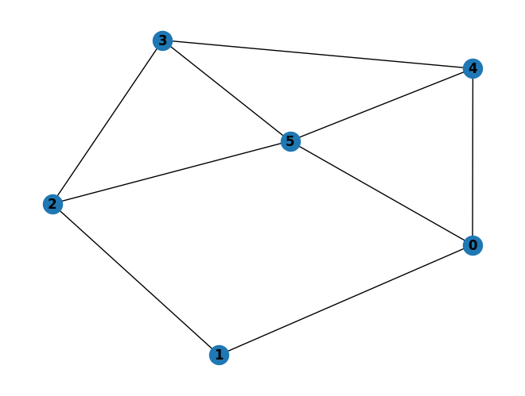

```python
nx.draw(G, with_labels=True, font_weight='bold')
```

```python
# let's create a directed version of the graph exactly as shown in image
H = nx.DiGraph({0: [1,5], 1: [2], 2: [3], 3: [4,5], 4: [0], 5: [2,4]})  # from dictionary
nx.adjacency_matrix(H).toarray()
```

```
array([[0, 1, 0, 0, 0, 1],
       [0, 0, 1, 0, 0, 0],
       [0, 0, 0, 1, 0, 0],
       [0, 0, 0, 0, 1, 1],
       [1, 0, 0, 0, 0, 0],
       [0, 0, 1, 0, 1, 0]])
```

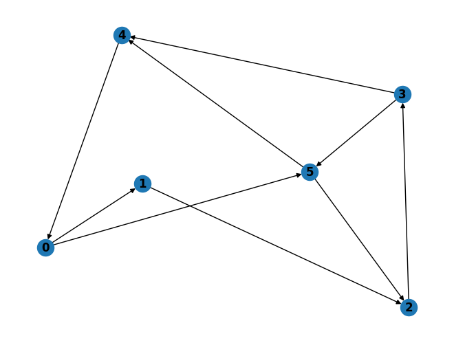

```python
nx.draw(H, with_labels=True, font_weight='bold')
```

## Question: Simple Graph Analysis using NetworkX

Define a new small-sized (directed or undirected) graph.

1. Find the [degrees of the nodes.](https://networkx.org/documentation/stable/reference/generated/networkx.classes.function.degree.html)
2. Find the [Laplacian matrix of the graph.](https://networkx.org/documentation/stable/reference/generated/networkx.linalg.laplacianmatrix.laplacian_matrix.html)
3. Check if it is [directed or not.](https://networkx.org/documentation/stable/reference/generated/networkx.classes.function.is_directed.html)
4. Find the [minimum spanning tree of the graph.](https://networkx.org/documentation/stable/reference/algorithms/generated/networkx.algorithms.tree.mst.minimum_spanning_tree.html)
5. Find the [shortest path between two nodes.](https://networkx.org/documentation/stable/reference/algorithms/generated/networkx.algorithms.shortest_paths.generic.shortest_path.html)

**Answer as text here**

#### Degree

The number of edges associated with a vertex $v$ is called the degree of that vertex, denoted $d(v)$. In particular, for edges $(v, v)$, then each such edge will make a contribution of 2 to $d(v)$.

For any undirected graph $G = (V, E)$, $\sum_{v \in V} d(v) = 2 \left| E \right|$. Corollary: In any intention, there must be an even number of points with odd degrees. isolated vertex: $d(v) = 0$, leaf vertex/pendant vertex: $d(v) = 1$, even vertex: $2 \mid d(v)$，odd vertex: $2 \nmid d(v)$, universal vertex: $d(v) = \left| V \right| - 1$, minimum degree: $\delta (G) = \min_{v \in G} d(v)$, maximum degree: $\Delta (G) = \max_{v \in G} d(v)$.

In a digraph $G = (V, E)$, the number of edges starting at a vertex $v$ is called the **out-degree** of that vertex, denoted $d^+(v)$. The number of edges ending in a vertex $v$ is called the **in-degree** of the node, denoted $d^-(v)$. Obviously, $d^+(v)+d^-(v)=d(v)$.

$\sum_{v \in V} d^+(v) = \sum_{v \in V} d^-(v) = \left| E \right|$.

#### Laplacian Matrix

The graph Laplacian is the matrix $L = D - A$, where A is the adjacency matrix and D is the diagonal matrix of node degrees.

Adjacency matrix is a square matrix used to represent a finite graph. The elements of the matrix indicate whether pairs of vertices are adjacent or not in the graph.

#### Minimum Spanning Tree (MST, 最小生成树)

Kruskal's algorithm is a common and easy-to-write minimum spanning tree algorithm, invented by Kruskal. The basic idea of this algorithm is to add edges from the smallest to the largest, and it is a greedy algorithm.

Prim algorithm is another common and easy to write minimum spanning tree algorithm. The basic idea of the algorithm is to start with a node and keep adding points (rather than adding edges as in Kruskal's algorithm).

The idea of Boruvka's algorithm is a combination of the previous two algorithms. It can be used to solve the minimum generating forest of undirected graphs. (An undirected connected graph is a minimal spanning tree.)

Note: Only connected graphs have generative trees, and for unconnected graphs, only generative forests exist.

#### Shortest Path

It's used to find the shortest path between any two nodes. The complexity is relatively high, but the constant is small and easy to implement (only three for). Applies to any graph, whether directed or undirected, with positive or negative edge weights, but the shortest circuit must exist. (Can't have a negative loop)

```
for (k = 1; k <= n; k++) {
  for (x = 1; x <= n; x++) {
    for (y = 1; y <= n; y++) {
      f[k][x][y] = min(f[k - 1][x][y], f[k - 1][x][k] + f[k - 1][k][y]);
    }
  }
}
```

Both the time complexity and space complexity are $O(N^3)$

Bellman-ford algorithm is a short-circuit algorithm based on the relax operation, which can find the short-circuit of a graph with negative weight, and can judge the absence of the short-circuit.

$$(u,v)dis(v) = \min(dis(v), dis(u) + w(u, v))$$

The Dijkstra algorithm was discovered by the Dutch computer scientist E. W. Dijkstra in 1956 and published in 1959. It is an algorithm for solving single source shortest path on non-negative weight graphs.

```
struct edge {
  int v, w;
};

struct node {
  int dis, u;

  bool operator>(const node& a) const { return dis > a.dis; }
};

vector<edge> e[MAXN];
int dis[MAXN], vis[MAXN];
priority_queue<node, vector<node>, greater<node>> q;

void dijkstra(int n, int s) {
  memset(dis, 0x3f, (n + 1) * sizeof(int));
  memset(vis, 0, (n + 1) * sizeof(int));
  dis[s] = 0;
  q.push({0, s});
  while (!q.empty()) {
    int u = q.top().u;
    q.pop();
    if (vis[u]) continue;
    vis[u] = 1;
    for (auto ed : e[u]) {
      int v = ed.v, w = ed.w;
      if (dis[v] > dis[u] + w) {
        dis[v] = dis[u] + w;
        q.push({dis[v], v});
      }
    }
  }
}
```

Time complexity: $O(m\log m)$

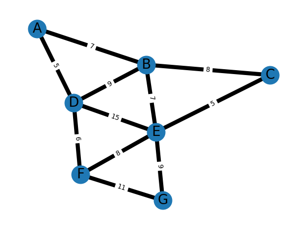

```
[('A', 2), ('B', 4), ('C', 2), ('D', 4), ('E', 5), ('F', 3), ('G', 2)]
[[ 12  -7   0  -5   0   0   0]
 [ -7  31  -8  -9  -7   0   0]
 [  0  -8  13   0  -5   0   0]
 [ -5  -9   0  35 -15  -6   0]
 [  0  -7  -5 -15  44  -8  -9]
 [  0   0   0  -6  -8  25 -11]
 [  0   0   0   0  -9 -11  20]]
False
[('A', 'D', {'weight': 5}), ('A', 'B', {'weight': 7}), ('B', 'E', {'weight': 7}), ('C', 'E', {'weight': 5}), ('D', 'F', {'weight': 6}), ('E', 'G', {'weight': 9})]
```

```
['A', 'D', 'F', 'G']
```

```python
''' Answer as code here '''
import networkx as nx
import matplotlib.pyplot as plt

G = nx.Graph()
G.add_edge("A", "B", weight = 7)
G.add_edge("B", "C", weight = 8)
G.add_edge("A", "D", weight = 5)
G.add_edge("B", "D", weight = 9)
G.add_edge("B", "E", weight = 7)
G.add_edge("C", "E", weight = 5)
G.add_edge("D", "E", weight = 15)
G.add_edge("D", "F", weight = 6)
G.add_edge("E", "F", weight = 8)
G.add_edge("E", "G", weight = 9)
G.add_edge("F", "G", weight = 11)

elist = [(u, v) for (u, v, d) in G.edges(data=True)]

pos = nx.spring_layout(G, seed=7)  # positions for all nodes - seed for reproducibility

# nodes
nx.draw_networkx_nodes(G, pos, node_size=700)

# edges
nx.draw_networkx_edges(G, pos, edgelist=elist, width=6)

# node labels
nx.draw_networkx_labels(G, pos, font_size=20, font_family="sans-serif")
# edge weight labels
edge_labels = nx.get_edge_attributes(G, "weight")
nx.draw_networkx_edge_labels(G, pos, edge_labels)

ax = plt.gca()
ax.margins(0.08)
plt.axis("off")
plt.tight_layout()
plt.show()

deg = nx.degree(G, nbunch=None, weight=None)
print(deg)
lap_mat = nx.laplacian_matrix(G, nodelist=None, weight='weight')
print(lap_mat.toarray().T)
print(nx.is_directed(G))
min_tree = nx.minimum_spanning_tree(G, weight='weight',
                                    algorithm='kruskal', ignore_nan=False)
print(min_tree.edges(data=True))

nx.shortest_path(G, source="A", target="G", weight="weight", method='dijkstra')
```

## Tree Data Type

A **Tree**) is a special case of a graph but is important in its own right and widely used. Each node in the tree can be connected to many children (depending on the type of tree) but must be connected to exactly one parent. The root (top-most) node of the tree has no parent by definition. Thus, there are no cycles or "loops" in trees and each child can be treated like the root node of its own subtree. Due to these properties, trees are relevant to [recursion](https://www.geeksforgeeks.org/recursion-on-trees-in-python/) algorithms and vice versa.

There is no built-in Tree library in Python but it is not difficult to [create one](https://www.w3schools.com/dsa/dsa_theory_trees.php). However, to save time, we introduce the [anytree library](https://anytree.readthedocs.io/en/latest/index.html) which provides a simple, lightweight, and extensible Tree data structure.

```python
from anytree import Node, RenderTree
udo = Node("Udo")
marc = Node("Marc", parent=udo)
lian = Node("Lian", parent=marc)
dan = Node("Dan", parent=udo)
jet = Node("Jet", parent=dan)

print(RenderTree(udo))
```

```
Node('/Udo')
├── Node('/Udo/Marc')
│   └── Node('/Udo/Marc/Lian')
└── Node('/Udo/Dan')
    └── Node('/Udo/Dan/Jet')
```

```python
marc.new_property = "awesome"
print(RenderTree(marc))
```

```
Node('/Udo/Marc', new_property='awesome')
└── Node('/Udo/Marc/Lian')
```

# Algorithms

Algorithms are the heart of computing and behind every reasonable computer program. As a simple definition: "An algorithm is a procedure to accomplish a speciﬁc task by taking inputs and transforming them into the desired output." Likewise simplified, *engineering* is about the application of scientific principles to design or build desired things. There is a close connection between algorithms, computing, and engineering, especially in the 21st century. *(note that, it is not that simple. There are multiple definitions of engineering and computer scientists still debate [what an algorithm is!](https://cacm.acm.org/opinion/what-is-an-algorithm/))*

## Recursion

We will start with one of the most common techniques used in designing algorithms: **recursion**. Recursive algorithms adopt a **reduction** or **divide-and-conquer** approach. Whatever the name used, the underlying principle is the same: break down a given (difficult) problem into smaller, more easily solved pieces. The idea is basically "simplify and delegate". Reducing one problem $X$ to another problem $Y$ means writing an algorithm for $X$ that uses an algorithm for $Y$ as a (black box) subroutine. A nice informal way of describing recursion (to solve a problem) is:

- If the given instance of the problem can be solved directly, solve it directly.
- Otherwise, reduce it to one or more simpler instances of the same problem. Note that, this approach is also closely related to induction in mathematics.

## Example: Binary Search

A **Binary Search Algorithm** is a searching algorithm (to find a number $x$ in a **sorted** array $Y=[y_0,y_1,\ldots,y_N]$), which repeatedly divides the search interval in half until it finds the target value or the interval is empty. This is a nice simple problem and algorithm for demonstrating the basic principles of recursion and divide-and-conquer approach.

```python
# It returns location of x in given array arr
def binarySearch(arr, low, high, x):

    while low <= high:

        mid = low + (high - low) // 2

        # Check if x is present at mid
        if arr[mid] == x:
            return mid+1

        # If x is greater, ignore left half
        elif arr[mid] < x:
            low = mid + 1

        # If x is smaller, ignore right half
        else:
            high = mid - 1

    # If we reach here, then the element was not present
    return False
```

```python
import numpy as np

#np.random.seed(126548451)
np.random.seed(12345678)
Y = np.random.randint(0,100, size=10) # random array of integers in [0,30]
Y = np.sort(np.unique(Y))             # remove duplicates and sort
print(Y)                             # search domain

x = 4  # searching for x in Y
result = binarySearch(Y, 0, len(Y)-1, x)
if result:
    print("Element ", x," is present at index", result-1," of the given array", Y)
else:
    print("Element ", x," is not present in the given array ", Y)
```

```
[ 4 31 43 47 49 51 56 80 97 98]
Element  4  is present at index 0  of the given array [ 4 31 43 47 49 51 56 80 97 98]
```

As an **exercise**, you can try different random arrays to explore how this algorithm works.

**There is one change to make: if the subscript of the target number is 0, then the return value becomes false, which causes an error. Therefore, when returning the subscript, the subscript value is increased by one. Subtract one printing.**

## Example: Fibonacci Numbers

The **[Fibonacci sequence](https://en.wikipedia.org/wiki/Fibonacci_sequence)** is a sequence in which each number is the sum of the two preceding ones. It is historically one of the most famous sequences due to its long history and recursive nature.

The definition is simple: $F_0=0$, $F_1=1$, and for $n>1$, $F_n=F_{n-1}+F_{n-2}$, which yields $[0, 1, 1, 2, 3, 5, 8, 13, 21, 34, 55, 89, 144, \ldots]$. The code below is from this [nice tutorial.](https://realpython.com/fibonacci-sequence-python/)

```python
# basic version without memoisation
def fibonacci_of(n):
    if n in {0, 1}:  # Base case
        return n
    return fibonacci_of(n - 1) + fibonacci_of(n - 2)  # Recursive case
```

```python
[fibonacci_of(n) for n in range(15)]
```

```
[0, 1, 1, 2, 3, 5, 8, 13, 21, 34, 55, 89, 144, 233, 377]
```

## Example: Tower of Hanoi

[figure not shown]

[Tower of Hanoi is a famous puzzle](https://en.wikipedia.org/wiki/Tower_of_Hanoi) that has been used to teach recursion to students for a long long time. To be honest, the recursive solution looks very much like magic, probably because it may be counter-intuitive to some.

There are many solutions online such as [this](https://runestone.academy/ns/books/published/pythonds/Recursion/TowerofHanoi.html), [another one](https://scipython.com/book/chapter-2-the-core-python-language-i/examples/the-tower-of-hanoi/) or [yet another one](https://www.geeksforgeeks.org/python-program-for-tower-of-hanoi/). Here is a solution that keeps track of the state of the system.

```python
# Recursive Python function to solve the Tower of Hanoi

# System state definition
# Rods are: A left, B middle, C right. A is source, C is destination. Smaller disks have a smaller number
state = {'A': [] , 'B': [], 'C' : []}

# Recursive DP algorithm
def TowerOfHanoi(n , source, destination, auxiliary):
    ## Trivial case
    if n==1:
        # update state
        disk = state[source].pop()
        state[destination].append(disk)
        print ("Move disk 1 from source",source,"to destination",destination, state)
        return
    ## STEP 1 of Algorithm
    TowerOfHanoi(n-1, source, auxiliary, destination)
    ## STEP 2 of Algorithm
    # update state
    disk = state[source].pop()
    state[destination].append(disk)
    print ("Move disk",n,"from source",source,"to destination",destination, state)
    ## STEP 3 of Algorithm
    TowerOfHanoi(n-1, auxiliary, destination, source)
```

```python
# Simulation
n = 6  # number of disks

# initial state setup
state = {'A': list(range(n,0,-1)), 'B': [], 'C' : []} # all disks in A, small disks have smaller numbers
print("Initial state of the tower ",state)

# solution
TowerOfHanoi(n,'A','C','B')
```

```
Initial state of the tower  {'A': [6, 5, 4, 3, 2, 1], 'B': [], 'C': []}
Move disk 1 from source A to destination B {'A': [6, 5, 4, 3, 2], 'B': [1], 'C': []}
Move disk 2 from source A to destination C {'A': [6, 5, 4, 3], 'B': [1], 'C': [2]}
Move disk 1 from source B to destination C {'A': [6, 5, 4, 3], 'B': [], 'C': [2, 1]}
Move disk 3 from source A to destination B {'A': [6, 5, 4], 'B': [3], 'C': [2, 1]}
Move disk 1 from source C to destination A {'A': [6, 5, 4, 1], 'B': [3], 'C': [2]}
Move disk 2 from source C to destination B {'A': [6, 5, 4, 1], 'B': [3, 2], 'C': []}
Move disk 1 from source A to destination B {'A': [6, 5, 4], 'B': [3, 2, 1], 'C': []}
Move disk 4 from source A to destination C {'A': [6, 5], 'B': [3, 2, 1], 'C': [4]}
Move disk 1 from source B to destination C {'A': [6, 5], 'B': [3, 2], 'C': [4, 1]}
Move disk 2 from source B to destination A {'A': [6, 5, 2], 'B': [3], 'C': [4, 1]}
Move disk 1 from source C to destination A {'A': [6, 5, 2, 1], 'B': [3], 'C': [4]}
Move disk 3 from source B to destination C {'A': [6, 5, 2, 1], 'B': [], 'C': [4, 3]}
Move disk 1 from source A to destination B {'A': [6, 5, 2], 'B': [1], 'C': [4, 3]}
Move disk 2 from source A to destination C {'A': [6, 5], 'B': [1], 'C': [4, 3, 2]}
Move disk 1 from source B to destination C {'A': [6, 5], 'B': [], 'C': [4, 3, 2, 1]}
Move disk 5 from source A to destination B {'A': [6], 'B': [5], 'C': [4, 3, 2, 1]}
Move disk 1 from source C to destination A {'A': [6, 1], 'B': [5], 'C': [4, 3, 2]}
Move disk 2 from source C to destination B {'A': [6, 1], 'B': [5, 2], 'C': [4, 3]}
Move disk 1 from source A to destination B {'A': [6], 'B': [5, 2, 1], 'C': [4, 3]}
Move disk 3 from source C to destination A {'A': [6, 3], 'B': [5, 2, 1], 'C': [4]}
Move disk 1 from source B to destination C {'A': [6, 3], 'B': [5, 2], 'C': [4, 1]}
Move disk 2 from source B to destination A {'A': [6, 3, 2], 'B': [5], 'C': [4, 1]}
Move disk 1 from source C to destination A {'A': [6, 3, 2, 1], 'B': [5], 'C': [4]}
Move disk 4 from source C to destination B {'A': [6, 3, 2, 1], 'B': [5, 4], 'C': []}
Move disk 1 from source A to destination B {'A': [6, 3, 2], 'B': [5, 4, 1], 'C': []}
Move disk 2 from source A to destination C {'A': [6, 3], 'B': [5, 4, 1], 'C': [2]}
Move disk 1 from source B to destination C {'A': [6, 3], 'B': [5, 4], 'C': [2, 1]}
Move disk 3 from source A to destination B {'A': [6], 'B': [5, 4, 3], 'C': [2, 1]}
Move disk 1 from source C to destination A {'A': [6, 1], 'B': [5, 4, 3], 'C': [2]}
Move disk 2 from source C to destination B {'A': [6, 1], 'B': [5, 4, 3, 2], 'C': []}
Move disk 1 from source A to destination B {'A': [6], 'B': [5, 4, 3, 2, 1], 'C': []}
Move disk 6 from source A to destination C {'A': [], 'B': [5, 4, 3, 2, 1], 'C': [6]}
Move disk 1 from source B to destination C {'A': [], 'B': [5, 4, 3, 2], 'C': [6, 1]}
Move disk 2 from source B to destination A {'A': [2], 'B': [5, 4, 3], 'C': [6, 1]}
Move disk 1 from source C to destination A {'A': [2, 1], 'B': [5, 4, 3], 'C': [6]}
Move disk 3 from source B to destination C {'A': [2, 1], 'B': [5, 4], 'C': [6, 3]}
Move disk 1 from source A to destination B {'A': [2], 'B': [5, 4, 1], 'C': [6, 3]}
Move disk 2 from source A to destination C {'A': [], 'B': [5, 4, 1], 'C': [6, 3, 2]}
Move disk 1 from source B to destination C {'A': [], 'B': [5, 4], 'C': [6, 3, 2, 1]}
```

[output cut: 9 more lines]

```
Move disk 1 from source A to destination B {'A': [4, 3, 2], 'B': [1], 'C': [6, 5]}
Move disk 2 from source A to destination C {'A': [4, 3], 'B': [1], 'C': [6, 5, 2]}
Move disk 1 from source B to destination C {'A': [4, 3], 'B': [], 'C': [6, 5, 2, 1]}
Move disk 3 from source A to destination B {'A': [4], 'B': [3], 'C': [6, 5, 2, 1]}
Move disk 1 from source C to destination A {'A': [4, 1], 'B': [3], 'C': [6, 5, 2]}
Move disk 2 from source C to destination B {'A': [4, 1], 'B': [3, 2], 'C': [6, 5]}
Move disk 1 from source A to destination B {'A': [4], 'B': [3, 2, 1], 'C': [6, 5]}
Move disk 4 from source A to destination C {'A': [], 'B': [3, 2, 1], 'C': [6, 5, 4]}
Move disk 1 from source B to destination C {'A': [], 'B': [3, 2], 'C': [6, 5, 4, 1]}
Move disk 2 from source B to destination A {'A': [2], 'B': [3], 'C': [6, 5, 4, 1]}
Move disk 1 from source C to destination A {'A': [2, 1], 'B': [3], 'C': [6, 5, 4]}
Move disk 3 from source B to destination C {'A': [2, 1], 'B': [], 'C': [6, 5, 4, 3]}
Move disk 1 from source A to destination B {'A': [2], 'B': [1], 'C': [6, 5, 4, 3]}
Move disk 2 from source A to destination C {'A': [], 'B': [1], 'C': [6, 5, 4, 3, 2]}
Move disk 1 from source B to destination C {'A': [], 'B': [], 'C': [6, 5, 4, 3, 2, 1]}
```

### Solution Analysis

It is like magic, isn't it? Try starting from $n=1$, and try increasing numbers of $n$. However, this may not be the best way to understand this. In fact, according to Prof Jeff Erickson (author of Algorithms book), this is not advised:

> It may be tempting to think about how all those smaller disks move around or more generally, what happens when the recursion is unrolled — but really, don’t do it. For most recursive algorithms, unrolling the recursion is neither necessary nor helpful. Our only task is to reduce the problem instance we’re given to one or more simpler instances or to solve the problem directly if such a reduction is impossible.

Maybe a better way to understand the solution algorithm is:

> The secret to solving this puzzle is to *think recursively*. Instead of trying to solve the entire puzzle at once, let’s concentrate on moving just the largest disk. We can’t move it at the beginning, because all the other disks are in the way. So ﬁrst we have to move those n-1 smaller disks to the spare peg **(Step 1)**. Once that’s done, we can move the largest disk directly to its destination **(Step 2)**. Finally, to ﬁnish the puzzle, we have to move the n-1 smaller disks from the spare peg to their destination **(Step 3)**. *That’s it! We’re done!* *We’ve successfully reduced the n-disk Tower of Hanoi problem to two instances of the (n-1)-disk Tower of Hanoi problem!*

The figure below summarises this line of thinking, followed by the simulation steps in the following. Note how the main steps of the algorithm unroll!

[figure not shown]

### *Optional Reading: why do some people find recursion counter-intuitive?*

Anecdotal evidence from (Computer Science) education indicates that students often find the concept of recursive programming difficult. I had serious difficulty understanding dynamic programming myself. Maybe it is very easy for some of you (especially if are used to thinking recursively).

Here are a few speculative ideas on why some people may find recursive thinking difficult and unintuitive:

- It almost seems like circular reasoning.
- When we give instructions to people or computers, we rarely direct them recursively. For example, imperative programming languages (including Python as well as Assembly) are mainly a series of instructions. Moreover, there is no recursion at the CPU level.
- When we solve problems we usually solve them step by step, iteratively, rather than recursively. Most recipes/tutorials are iterative (repeat ... until, while ... do).
- As the puzzle above shows, it is hard to keep track of how a recursive algorithm changes the system state (or works). Unrolling recursion requires the mental construction of a large tree rather than a simple loop (and is not advised). Maybe because of this recursive algorithms are to interpret intuitively.
- It is hard to describe the solution using the system state, which would require unrolling.

*What do you think?*

In my opinion, the key point is: **Understand the role of a function and believe that it can complete the task, do not explore more details** (A human brain can store few stacks).

This is the [Hanoi Tower Wikipedia](https://en.wikipedia.org/wiki/Tower_of_Hanoi).

### Recursive

The basic idea of recursion is that a function directly or indirectly calls itself, so that the solution of the original problem is transformed into many smaller subproblems of the same nature. When solving the problem, we only need to pay attention to how to divide the original problem into sub-problems that meet the conditions, and do not need to pay too much attention to how the sub-problem is solved.

The two most important features of recursive code are the end condition and the self-call. The self-call is the solution to the subproblem, and the end condition defines the answer to the simplest subproblem.

```
int func(input) {
  if (end condition) return Solution to the smallest problem;
  return func(smaller input);
}
```

Recursive is more concise and less error-prone than circular writing. However, recursion is implemented using the stack. Each time a function call is entered, a layer of stack frames is added to the stack and each time a function is returned, the stack is reduced by a layer of stack frames. The stack is not infinite, and when the number of recursive layers is too large, it will cause **stack overflow**.

### Divide and Conquer

The divide-and-conquer algorithm is based on recursion. The process can be divided into three steps: decomposition -> Resolution -> Merge.

## Question: Find the Powerset a given Set

The [powerset](https://en.wikipedia.org/wiki/Power_set) of a set $S$ is defined as *the set of all subsets of S, including the empty set and S itself.*

For a given set (of numbers for convenience), find the powerset using a **recursive** algorithm. There is an iterative solution but that is not what we want here.

**Hints:**

1. Use list data type as input and in your code.
2. The [Wikipedia article](https://en.wikipedia.org/wiki/Power_set) provides the algorithm you need!

```python
import numpy as np
import random

np.random.seed(1252334531)
Sarr = np.random.randint(0, 100, size=4) # random array of integers in [0,100]
Sarr = np.sort(np.unique(Sarr))
S = [str(x) for x in Sarr]
S
```

```
['16', '48', '74', '86']
```

**Answer as text here**

Consider the set operation, we can use binary notation: 0 for non-existence and 1 for existence. Hence, $mark \in [0, 2^n - 1]$ can be used to represent all power sets.

| 0000 | 0001 | 0010 | 0011 | 0100 | 0101 | 0110 | 0111 | ... | 1111 |
| --- | --- | --- | --- | --- | --- | --- | --- | --- | --- |
| [] | [16] | [48] | [16,48] | [74] | [16,74] | [48,74] | [16,48,74] | ... | [16,48,74,86] |

There are two ways I have in mind:

- Enumerate subsets iteratively
- Use recursion method

### Enumerate subsets iteratively

Consider the array [1, 2, 2] and choose the first two numbers, or the first three numbers, to get the same subset. We can sort the array first. During iteration, if no previous number is selected and the current number is the same as the previous number, the currently generated subset can be skipped.

The time complexity is $O(n\times 2^n)$ (since the sort time complexity $O(n\log n)$ is less than $O(n\times 2^n)$), space complexity is $O(n)$.

```python
''' Answer as code here '''
def subsets_inter(nums: list[int]) -> list[list[int]]:
    nums.sort()
    n = len(nums)
    ans = []
    for mask in range(1 << n):
        t = []
        flag = True
        for i in range(n):
            if mask & (1 << i):
                if i > 0 and not (mask & (1 << (i - 1))) and nums[i] == nums[i - 1]:
                    flag = False
                    break
                t.append(nums[i])
        if flag:
            ans.append(t)
    return ans

subsets_inter(S)
```

```
[[],
 ['16'],
 ['48'],
 ['16', '48'],
 ['74'],
 ['16', '74'],
 ['48', '74'],
 ['16', '48', '74'],
 ['86'],
 ['16', '86'],
 ['48', '86'],
 ['16', '48', '86'],
 ['74', '86'],
 ['16', '74', '86'],
 ['48', '74', '86'],
 ['16', '48', '74', '86']]
```

### Recursion method

Same idea as above.

```python
def subsets_recu(nums: list[int]) -> list[list[int]]:
    nums.sort()
    ans = []
    t = []

    def dfs(pre: bool, cur: int):
        if cur == len(nums):
            ans.append(t[:])
            return
        dfs(False, cur + 1)
        if not pre and cur > 0 and nums[cur] == nums[cur - 1]:
            return
        t.append(nums[cur])
        dfs(True, cur + 1)
        t.pop()

    dfs(False, 0)
    return ans

subsets_recu(S)
```

```
[[],
 ['86'],
 ['74'],
 ['74', '86'],
 ['48'],
 ['48', '86'],
 ['48', '74'],
 ['48', '74', '86'],
 ['16'],
 ['16', '86'],
 ['16', '74'],
 ['16', '74', '86'],
 ['16', '48'],
 ['16', '48', '86'],
 ['16', '48', '74'],
 ['16', '48', '74', '86']]
```

## Sorting

[Sorting algorithms](https://en.wikipedia.org/wiki/Sorting_algorithm) provide a nice introduction to divide-and-conquer and recursion approaches, which are fundamental to many other algorithms. Unsurprisingly, almost every introductory algorithm book focuses on them.

**Sorting problem:** Take a (finite) sequence of elements as *input* and order them at the *output* according to a rule, e.g. from small to larger.

The general divide and conquer algorithm pattern:

1. Divide the given instance of the problem into several independent smaller instances of the same problem.
2. Conquer by applying the recursive solution to each smaller/simpler instance.
3. Combine the solutions for the smaller instances into the ﬁnal solution.

## Question: Mergesort Algorithm

Implement the well-known [mergesort algorithm](https://www.w3schools.com/dsa/dsa_algo_mergesort.php). The steps of the algorithm are:

> - Divide the unsorted array into two sub-arrays, half the size of the original.
> - Continue to divide the sub-arrays as long as the current piece of the array has more than one element.
> - Merge two sub-arrays by always putting the lowest value first.
> - Keep merging until there are no sub-arrays left.

## *Optional Question: Quicksort Algorithm*

Implement the well-known [quicksort algorithm](https://www.w3schools.com/dsa/dsa_algo_quicksort.php). The steps of the algorithm are:

> - Choose a value in the array to be the pivot element.
> - Order the rest of the array so that lower values than the pivot element are on the left, and higher values are on the right.
> - Swap the pivot element with the first element of the higher values so that the pivot element lands in between the lower and higher values.
> - Do the same operations (recursively) for the sub-arrays on the left and right sides of the pivot element.

Refer to Chapter 1 of the Algorithms book for both in addition to numerous online resources.

**Answer as text here**

### Mergesort

1. Request a space whose size is the sum of two sorted sequences, and this space is used to store the combined sequence;
2. Sets two Pointers, the initial position of which is the starting position of the two sorted sequences;
3. Compare the elements that the two Pointers point to, select the relatively small element to put into the merge space, and move the pointer to the next position;
4. Repeat step 3 until a pointer reaches the end of the sequence;
5. Copies all remaining elements of another sequence directly to the end of the merge sequence.

[figure not shown]

The time complexity is $O (n \log n)$ in the optimal, worst and average cases, and the space complexity is $O (n)$.

```python
''' Answer as code here '''
import random

random.seed(12345678)
arr = [random.randrange(1, 100) for i in range(1, 10)]
print("pre_arr: ", arr)
```

```
pre_arr:  [93, 13, 82, 76, 30, 98, 33, 78, 66]
```

```python
def merge(left, right):
    sorted_arr = []
    i = j = 0

    # 比较两个子列表的元素，按顺序合并
    while i < len(left) and j < len(right):
        if left[i] < right[j]:
            sorted_arr.append(left[i])
            i += 1
        else:
            sorted_arr.append(right[j])
            j += 1

    # 将剩余的元素添加到结果中
    sorted_arr.extend(left[i:])
    sorted_arr.extend(right[j:])
    return sorted_arr

def merge_sort(arr):
    if len(arr) <= 1:
        return arr

    # 分解：将列表分成两半
    mid = len(arr) // 2
    left_half = merge_sort(arr[:mid])  # 递归排序左半部分
    right_half = merge_sort(arr[mid:])  # 递归排序右半部分

    # 合并：将两个有序子列表合并
    return merge(left_half, right_half)

print("pre_arr: ", arr)
sorted_arr = merge_sort(arr)
print("sorted_arr: ", sorted_arr)
```

```
pre_arr:  [93, 13, 82, 76, 30, 98, 33, 78, 66]
sorted_arr:  [13, 30, 33, 66, 76, 78, 82, 93, 98]
```

### Quicksort

1. Select the base element: Select an element from the list as the base (pivot). The selection method can be first element, last element, intermediate element, or random element.
2. Partition: Rearranges the list so that all elements smaller than the base element are to the left of the base and all elements larger than the base element are to the right of the base. The location of the base element is determined after the partitioning is complete.
3. Recursive sort: Quicksort the sublists to the left and right of the base element recursively, respectively.
4. Merge: Since the partitioning operation is performed in place, the entire list is already in order after the recursion is over.

[figure not shown]

Quicksort is an unstable sorting algorithm.

The optimal and average time complexity of quicksort is $O(n\log n)$, and the worst time complexity is $O(n^2)$.

```python
def quicksort(arr: list) -> list:
    if len(arr) <= 1:
        return arr

    pivot = arr[-1]

    left = [i for i in arr[:-1] if i <= pivot]
    right = [i for i in arr[:-1] if i > pivot]

    return quicksort(left) + [pivot] + quicksort(right)

print("pre_arr: ", arr)
sorted_arr = quicksort(arr)
print("sorted_arr: ", sorted_arr)
```

```
pre_arr:  [93, 13, 82, 76, 30, 98, 33, 78, 66]
sorted_arr:  [13, 30, 33, 66, 76, 78, 82, 93, 98]
```

In order to prevent the worst case scenario (where the delimited value of each selection is the maximum value of the sequence), there are several more mature optimization methods for quick sorting:

- 3-way Radix Quicksort: This is a mix of quicksort and radix sort.
- Introspective sort: This is a combination of quicksort and heapsort.

## Dynamic Programming

Dynamic Programming (DP) is a method for designing algorithms. DP gives us a way to design custom algorithms that systematically search all possibilities (thus guaranteeing correctness) while storing results to avoid recomputing (thus providing eﬃciency). By storing the consequences of all possible decisions and using this information in a systematic way, the total amount of work is minimized. In a nutshell, dynamic programming is recursion without repetition.

Dynamic programming eﬃciently implements a recursive algorithm by storing partial results. Hence, DP (via Memoization) essentially trades oﬀ space for time.

Once you understand it, DP is probably the easiest algorithm design technique to apply in practice. Until you understand it, DP seems like magic.

## Example: Fibonacci numbers revisited

Let's try compute Fibonacci numbers with memoisation to improve efficiency. Then, we look at the iterative version with tabulation.

```python
# Fibonacci with memoisation
cache = {0: 0, 1: 1}   # remember dictionaries are (now) ordered

def fibonacci_of_wm(n):
    if n in cache:  # Base case
        return cache[n]
    # Compute and cache the Fibonacci number
    cache[n] = fibonacci_of_wm(n - 1) + fibonacci_of_wm(n - 2)  # Recursive case
    return cache[n]
```

```python
[fibonacci_of_wm(n) for n in range(15)]
```

```
[0, 1, 1, 2, 3, 5, 8, 13, 21, 34, 55, 89, 144, 233, 377]
```

```python
print(cache)
```

```
{0: 0, 1: 1, 2: 1, 3: 2, 4: 3, 5: 5, 6: 8, 7: 13, 8: 21, 9: 34, 10: 55, 11: 89, 12: 144, 13: 233, 14: 377}
```

```python
# Fibonacci iterative with tabulation version without recursion
def fibonacci_of_tab(n):

    # Handle the base cases
    if n in {0, 1}:
        return n

    previous, fib_number = 0, 1
    for _ in range(2, n + 1):
        # Compute the next Fibonacci number, remember the previous one
        previous, fib_number = fib_number, previous + fib_number
        # note that there are no recursive calls to the function in this version!

    return fib_number
```

```python
[fibonacci_of_tab(n) for n in range(15)]
```

```
[0, 1, 1, 2, 3, 5, 8, 13, 21, 34, 55, 89, 144, 233, 377]
```

## Question: Fast Multiplication

It is possible to improve efficiency of multiplication compared to the classical (goes back to antiquity) version, also known as long multiplication, you learned in primary school. You can [read here](https://www.quantamagazine.org/new-breakthrough-brings-matrix-multiplication-closer-to-ideal-20240307/) why speeding up multiplication matters and recent efforts on this.

The idea for speeding it up is based on a divide-and-conquer approach as shown in this formula: $$ (10^m a + b)(10^m c + d) = 10^{2m} ac + 10^m (bc + ad) + bd .$$ The resulting algorithm (from Chapter 1 in Algoiorthms book) is shown here in pseudo-code:

[figure not shown]

1. Implement split multiply in Python using a recursive function.
2. An improvement on this is known as [Karatsuba algorithm](https://en.wikipedia.org/wiki/Karatsuba_algorithm), which requires only three multiplications. Read about it from the given link and implement this more efficient version.

**Answer as text here**

```python
''' Answer as code here '''
def SplitMultiply(x, y, n):

    if n == 1:
        return x*y

    else:
        m = (n + 1) // 2
        a = x // (10 ** m)
        b = x % (10 ** m)
        c = y // (10 ** m)
        d = y % (10 ** m)
        e = SplitMultiply(a, c, m)
        f = SplitMultiply(b, d ,m)
        g = SplitMultiply(b, c, m)
        h = SplitMultiply(a, d, m)

        return 10 ** (2 * m) * e + 10 ** m * (g + h) + f
```

```python
ans = SplitMultiply(11, 11, 3)
```

## Example: Knapsack Problem

[figure not shown]

The [knapsack problem](https://en.wikipedia.org/wiki/Knapsack_problem) is a well-known canonical problem in combinatorial optimisation formulated as

> Given a set of $N$ items, each with a weight $w$ and a value $v$, determine which items to include in the collection (bag) so that the total weight, $\sum_i w_i x_i$, is less than or equal to a given limit (bag capacity $W$) and the total value, $\sum_i v_i x_i$, is as large as possible (maximised).

The 0-1 knapsack problem can be formally stated as $$ \max_x \sum_{i=1}^N v_i x_i \quad \rm{s.t.} \quad \sum_{i=1}^N w_i x_i \leq W, \; x_i \in \{0, 1\} \; \forall i.$$

A [recursive, brute-force solution](https://www.w3schools.com/dsa/dsa_ref_knapsack.php) to the problem is given below. Another implementation is [here](https://www.geeksforgeeks.org/0-1-knapsack-problem-dp-10/).

The [brute force algorithm](https://www.w3schools.com/dsa/dsa_ref_knapsack.php) steps are:

> 1. Consider each item one at a time.
>    1. If there is capacity left for the current item, add it by adding its value and reducing the remaining capacity with its weight. Then call the function on itself for the next item.
>    2. Also, try not adding the current item before calling the function on itself for the next item.
> 2. Return the maximum value from the two scenarios above (adding the current item, or not adding it).

```python
def knapsack_brute_force(capacity, n):
    print(f"knapsack_brute_force({capacity},{n})")
    if n == 0 or capacity == 0:
        return 0

    elif weights[n-1] > capacity:
        return knapsack_brute_force(capacity, n-1)

    else:
        include_item = values[n-1] + knapsack_brute_force(capacity-weights[n-1], n-1)
        exclude_item = knapsack_brute_force(capacity, n-1)
        return max(include_item, exclude_item)

values = [300, 200, 400, 500]
weights = [2, 1, 5, 3]
capacity = 10
n = len(values)

print("\nMaximum value in Knapsack =", knapsack_brute_force(capacity, n))
```

```
knapsack_brute_force(10,4)
knapsack_brute_force(7,3)
knapsack_brute_force(2,2)
knapsack_brute_force(1,1)
knapsack_brute_force(1,0)
knapsack_brute_force(2,1)
knapsack_brute_force(0,0)
knapsack_brute_force(2,0)
knapsack_brute_force(7,2)
knapsack_brute_force(6,1)
knapsack_brute_force(4,0)
knapsack_brute_force(6,0)
knapsack_brute_force(7,1)
knapsack_brute_force(5,0)
knapsack_brute_force(7,0)
knapsack_brute_force(10,3)
knapsack_brute_force(5,2)
knapsack_brute_force(4,1)
knapsack_brute_force(2,0)
knapsack_brute_force(4,0)
knapsack_brute_force(5,1)
knapsack_brute_force(3,0)
knapsack_brute_force(5,0)
knapsack_brute_force(10,2)
knapsack_brute_force(9,1)
knapsack_brute_force(7,0)
knapsack_brute_force(9,0)
knapsack_brute_force(10,1)
knapsack_brute_force(8,0)
knapsack_brute_force(10,0)

Maximum value in Knapsack = 1200
```

### Analysis with a tree structure

As in the case of Tower of Hanoi, this output tells us almost nothing. It is much easier to [interpret the output](https://www.w3schools.com/dsa/dsa_ref_knapsack.php) if we consider the solution in terms of a tree rather than an iterative loop. After all, this is exactly what the recursive algorithm does! Therefore, we create a tree to store the output of the recursive algorithm.

```python
from anytree import Node, RenderTree, Walker

# Use a simple tree to store solutions
root_node = Node("Start")     # the solution tree
root_node.val = 0             # temp variable to store the calculated value
root_node.total_val = 0       # the total value of a solution
root_node.soln_node = []      # the solution node/branch

def knapsack_brute_force(capacity, n, node, verbose):
    if verbose:               # write output or not
        print(f"knapsack_brute_force({capacity},{n})")

    # out of items or capacity
    if n == 0 or capacity == 0:
        return 0

    # if weight of item is more than capacity, skip it
    elif weights[n-1] > capacity:  # n starts from end of list, then n-1, n-2, until 0
        return knapsack_brute_force(capacity, n-1, node, verbose)

    # crate two branches one that includes the next item and one that does not
    else:
        # -------------------------------------------
        # create and store new item node in the tree
        new_node = Node(str((values[n-1], weights[n-1])), parent = node)
        new_node.val = values[n-1] + node.val # cumulative value
        # is this the current solution?
        if new_node.val > root_node.total_val:  # assuming one solution for simplicity here
            root_node.total_val = new_node.val  # if current soln, then store cumulative value
            root_node.soln_node = new_node    # store solution
        # -------------------------------------------
        # Main Algorithm
        # branch that includes the item
        include_item = values[n-1] + knapsack_brute_force(capacity-weights[n-1], n-1, new_node, verbose)
        # branch that does not include the item
        exclude_item = knapsack_brute_force(capacity, n-1, node, verbose)
        # return the final value
        return max(include_item, exclude_item)
```

```python
# Problem definition
values = [300, 200, 400, 500]  # v, item values
weights = [2, 1, 5, 3]         # w, item weights
capacity = 10                  # W, bag capacity
n = len(values)                # total number of items
```

```python
print("\nMaximum value in Knapsack =", knapsack_brute_force(capacity, n, root_node, False))
```

```
Maximum value in Knapsack = 1200
```

```python
print(RenderTree(root_node))
```

```
Node('/Start', soln_node=Node('/Start/(500, 3)/(400, 5)/(300, 2)', val=1200), total_val=1200, val=0)
├── Node('/Start/(500, 3)', val=500)
│   ├── Node('/Start/(500, 3)/(400, 5)', val=900)
│   │   ├── Node('/Start/(500, 3)/(400, 5)/(200, 1)', val=1100)
│   │   └── Node('/Start/(500, 3)/(400, 5)/(300, 2)', val=1200)
│   ├── Node('/Start/(500, 3)/(200, 1)', val=700)
│   │   └── Node('/Start/(500, 3)/(200, 1)/(300, 2)', val=1000)
│   └── Node('/Start/(500, 3)/(300, 2)', val=800)
├── Node('/Start/(400, 5)', val=400)
│   ├── Node('/Start/(400, 5)/(200, 1)', val=600)
│   │   └── Node('/Start/(400, 5)/(200, 1)/(300, 2)', val=900)
│   └── Node('/Start/(400, 5)/(300, 2)', val=700)
├── Node('/Start/(200, 1)', val=200)
│   └── Node('/Start/(200, 1)/(300, 2)', val=500)
└── Node('/Start/(300, 2)', val=300)
```

```python
print(root_node.soln_node)
#print(root_node.soln_node.parent)
walk = Walker()
walk.walk(root_node,root_node.soln_node)
```

```
Node('/Start/(500, 3)/(400, 5)/(300, 2)', val=1200)
```

```
((),
 Node('/Start', soln_node=Node('/Start/(500, 3)/(400, 5)/(300, 2)', val=1200), total_val=1200, val=0),
 (Node('/Start/(500, 3)', val=500),
  Node('/Start/(500, 3)/(400, 5)', val=900),
  Node('/Start/(500, 3)/(400, 5)/(300, 2)', val=1200)))
```

## Question: Memoization Approach for 0/1 Knapsack Problem

Extend the brute force algorithm above by creating either (a) an array *memo* or (b) the given tree, to store previous results. To avoid doing the same calculation more than once, every time you call your function, check first if the result is already stored.

**Answer as text here**

The known conditions are the weight of item i $w_{i}$, the value $v_{i}$, and the total capacity of the backpack W. Let DP state $f_{i,j}$be the maximum total value that can be achieved by a backpack of capacity j when only the first i items can be placed in it. Consider transferring. Assuming that all states of the previous i-1 items have been handled, then for the I-th item, when it is not put into the backpack, the remaining capacity of the backpack is unchanged, and the total value of the items in the backpack is unchanged, so the maximum value of this case is $f_{i-1,j}$; When it is put into the backpack, the remaining capacity of the backpack will decrease by $w_{i}$, and the total value of the items in the backpack will increase by $v_{i}$, so the maximum value in this case is $f_{i-1,j-w_{i}}+v_{i}$. From this, the state transition equation can be derived: $$f_{i,j}=\max(f_{i-1,j},f_{i-1,j-w_{i}}+v_{i})$$

The time complexity is $O(nW)$, space complexity is $O(nW)$

```python
import numpy as np

def complex_knapsack_dp(w: list, v: list, W: int, n: int):
    f = np.zeros((n + 1, W + 1), dtype=int)
    for i in range(1, n + 1):
        for j in range(1, W + 1):
            if j < w[i - 1]:
                f[i][j] = f[i - 1][j]
            else:
                f[i][j] = max(f[i - 1][j], f[i - 1][j - w[i - 1]] + v[i - 1])
    print(f)
    return f[n][W]

complex_knapsack_dp(weights, values, capacity, n)
```

```
[[   0    0    0    0    0    0    0    0    0    0    0]
 [   0    0  300  300  300  300  300  300  300  300  300]
 [   0  200  300  500  500  500  500  500  500  500  500]
 [   0  200  300  500  500  500  600  700  900  900  900]
 [   0  200  300  500  700  800 1000 1000 1000 1100 1200]]
```

```
np.int64(1200)
```

Consider using a scrolling array for optimization. But this array needs to be traversed in reverse order. Since only $f_{i-1}$ has an impact on $f_i$, the first dimension can be removed and the maximum value of the backpack capacity of i can be expressed directly with $f_{i}$ when the current item is processed, and the following equation can be obtained: $$f_j=\max \left(f_j,f_{j-w_i}+v_i\right)$$

Therefore, the core code is:

```
for i in range(1, n + 1):
    for l in range(W, w[i] - 1, -1):
        f[l] = max(f[l], f[l - w[i]] + v[i])
```

The time complexity is still $O(nW)$, but space complexity is down to $O(W)$

```python
''' Answer as code here '''
'''
w: weight of each items
v: value
W: total capacity of the backpack
'''
def knapsack_dp(w: list, v: list, W: int, n: int):
    f = [0 for i in range(W+1)]
    for i in range(0, n):
        for j in range(W, w[i] - 1, -1):
            f[j] = max(f[j], f[j - w[i]] + v[i])
        print(f)
    return f[W]

knapsack_dp(weights, values, capacity, n)
```

```
[0, 0, 300, 300, 300, 300, 300, 300, 300, 300, 300]
[0, 200, 300, 500, 500, 500, 500, 500, 500, 500, 500]
[0, 200, 300, 500, 500, 500, 600, 700, 900, 900, 900]
[0, 200, 300, 500, 700, 800, 1000, 1000, 1000, 1100, 1200]
```

```
1200
```

# Workshop Assessment Instructions

*You should complete the workshop tasks and answer the questions within the allocated session!* **Submission deadline is usually the end of the last week of the workshop. Please check Canvas for the exact deadline!**

It is **mandatory to follow all of the submission guidelines** given below. *Don't forget the Report submission information on top of this notebook!*

1. The completed Jupyter Notebook and its PDF version (you can simply print-preview and then print as PDF from within your browser) should be uploaded to the right place in Canvas. *It is your responsibility to follow the announcements!* **Late submissions will be penalised (up to 100% of the total mark depending on the delay amount)!**
2. Filename should be “ELEN90088 Workshop **W: StudentID1-StudentID2** of session **Day-Time**", where **W** refers to the workshop number, **StudentID1-StudentID2** are your student numbers, **Day-Time** is your session day and time, e.g. *Tue-14*.
3. Answers to questions, simulation results and diagrams should be included in the Jupyter Notebook as text, code, and plots. *If you don't know latex, you can write formulas/text to a paper by hand, scan it and then include it as an image within Markdown cells.*
4. Please submit your report as a group.

## Workshop Marking

- Each workshop has a fixed number of points corresponding to a certain percentage of the total subject mark inclusive individual oral examination. You can find the detailed rubrics on Canvas.
- Individual oral quizzes will be scheduled within the next two weeks following the report submission. They will be during workshop hours. Therefore, you must attend the workshops!
- The individual oral examination will assess your answers to workshop questions, what you have done in that workshop, and your knowledge of the subject material in association with the workshop.

## Additional guidelines for your programs:

- Write modular code using functions.
- Properly indent your code. But Python forces you to do that anyway ;)
- Heavily comment on the code to describe your implementation and to show your understanding. No comments, no credit!
- Make the code your own! It is encouraged to find and get inspired by online examples but you should exactly understand, modify as needed, and explain your code via comments. If you resort to blind copy/paste, you will certainly not do well in the individual oral quizzes.